# przyczyny stopniowego karłowacenia śledzi oceanicznych wyławianych w Europie

Radosław Burdziński

2022-11-15

# Executive summary

Cel analizy to znalezienie przyczyny stopniowego karłowacenia śledzi oceanicznych wyławianych w Europie. Pomiary zawierają obserwacje z ostatnich 60 lat. Pomiary opisano przy pomocy 16 atrybutów:

- **length** : długość złowionego śledzia [cm],
- **cfin1**: dostępność planktonu [zagęszczenie Calanus finmarchicus gat. 1],
- **cfin2**: dostępność planktonu [zagęszczenie Calanus finmarchicus gat. 2],
- **chel1**: dostępność planktonu [zagęszczenie Calanus helgolandicus gat. 1],
- **chel2**: dostępność planktonu [zagęszczenie Calanus helgolandicus gat. 2],
- **lcop1**: dostępność planktonu [zagęszczenie widłonogów gat. 1],
- **lcop2**: dostępność planktonu [zagęszczenie widłonogów gat. 2],
- **fbar**: natężenie połowów w regionie [ułamek pozostawionego narybku],
- **recr**: roczny narybek [liczba śledzi],
- **cumf**: łączne roczne natężenie połowów w regionie [ułamek pozostawionego narybku],
- **totaln**: łączna liczba ryb złowionych w ramach połowu [liczba śledzi],
- **sst**: temperatura przy powierzchni wody [°C],
- **sal**: poziom zasolenia wody [Knudsen ppt],
- **xmonth**: miesiąc połowu [numer miesiąca],
- **nao**: oscylacja północnoatlantycka [mb]

# Wykorzystane biblioteki

```r
library(dplyr)
library(tidyr)
library(ggplot2)
library(caret)
library(grid)
library(gridExtra)
library(tibble)
library(gganimate)
library(gifski)
```

# Wczytywanie danych z pliku

```r
    initial <- read.csv("sledzie.csv", nrows=100)
    classes <- sapply(initial, class)
    sledzie <- read.csv("sledzie.csv",
                     colClasses = classes)
```

## Wstępne przetwarzanie danych

Brakujące wartości w zbiorze zastąpione są znakiem “?”. Rekordy posiadające takie wartości zostały usunięte z ze zbioru danych. Rekordy nie posiadają atrbutu oznaczającego rok w którym dokonano obserwacji, jednak na podstawie dostarczonych danych utworzono nową kolumnę **Year** zawierającą tę informację. W tym celu wykorzystano atrybut **recr** - roczny narybek. Dodatkowo usunięto ze zbioru danych kolumnę oznaczającą index danej obserwacji.

```r
  sledzie <-  data.frame(lapply(sledzie,as.numeric))
  sledzie <-  sledzie[complete.cases(sledzie),]
  sledzie <- sledzie[,-1]

  years <-  sledzie %>% distinct(recr2=as.factor(recr)) %>% mutate(year=seq(1, length(recr2), 1))
  sledzieWithYear <- merge(sledzie, years, by.x = "recr", by.y = "recr2")
```

# Sekcja podsumowującą rozmiar zbioru i podstawowe statystyki.

Zbiór danych po wstępnym przetwarzaniu składa sie z : 42488 rekordów opisanych przy pomocy 15 atrybutów:

## Średnie wartości atrybutów

| length | cfin1 | cfin2 | chel1 | chel2 | lcop1 | lcop2 | fbar | recr | cumf | totaln | sst | sal |
| --- | --- | --- | --- | --- | --- | --- | --- | --- | --- | --- | --- | --- |
| 25.30457 | 0.4456616 | 2.026913 | 10.01573 | 21.19669 | 12.83863 | 28.39551 | 0.3305674 | 519877.3 | 0.2298664 | 515082 | 13.87496 | 35.50981 |

## Analiza wartości atrybutów

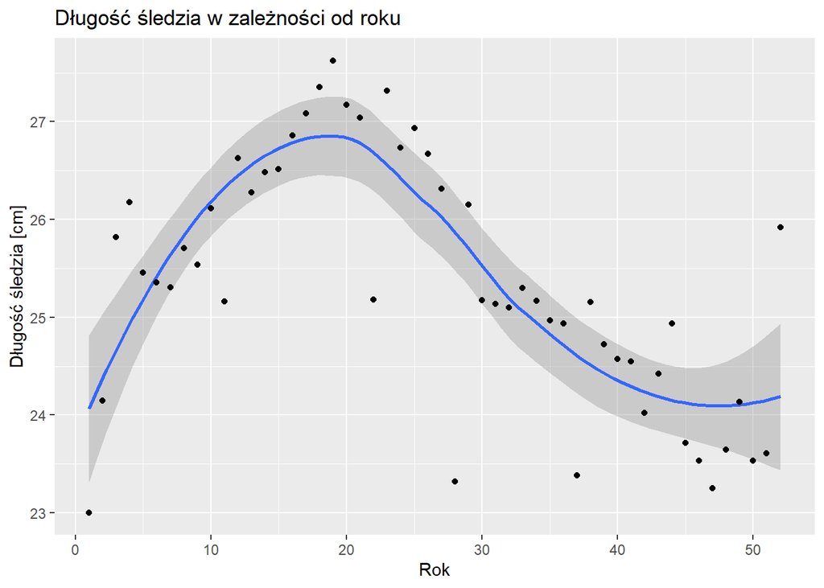

```r
year_mean <- sledzieWithYear %>% group_by(year) %>% summarise_at(vars(length), list(mean, sd))
  ggplot(year_mean, aes(x=year, y=fn1)) +
    geom_smooth() +
    geom_point()  +
    labs(title="Długość śledzia w zależności od roku",x="Rok",y="Długość śledzia [cm]")
```

Powyższy wykres przedstawia zagregowane, poprzez średnią, dane dotyczące długości śledzia w zależności od roku obliczonego na podstawie atrybutu **recr**. Możemy z niego odczytać, iż w ostatnich latach, nastąpił spadek średniej długości śledzia. Jednak warto odnotować niewielki wzrost na końcu wykresu.

### Rozkłady wartości poszczególnych atrybutów

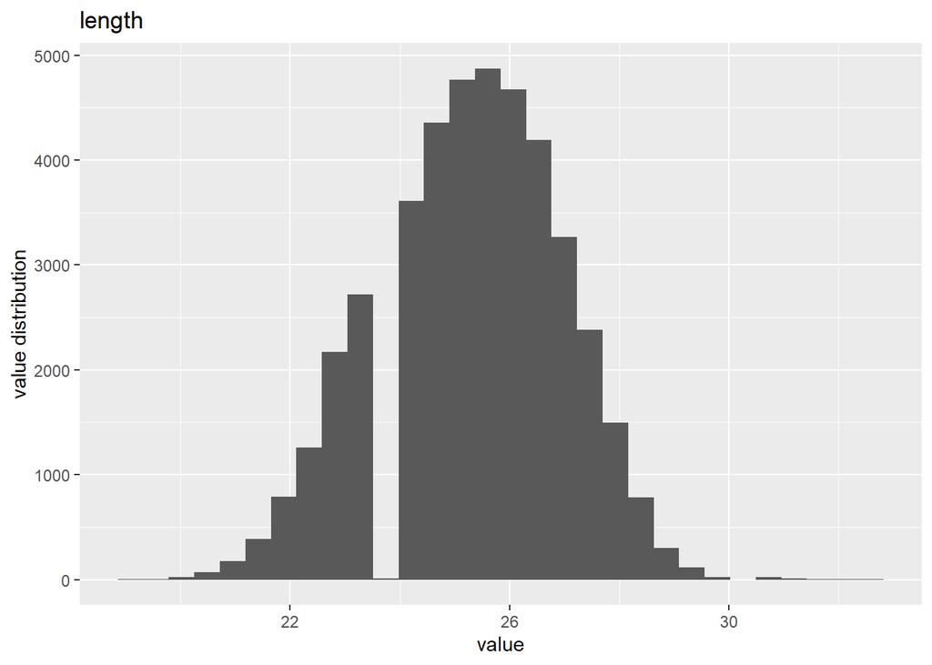

```r
lengthPlot
```

Na podstawie rozkładu wartości długości śledzia możemy stwierdzić, iż długość śledzia oscyluje pomiędzy 19, a 32 centymetra. Zdecydownie najwięcej śledzi ma długość o wartości od 24 do 26 centymetrów. Widzimy również, że rozkład długości śledzia przypomina rozkład normalny.

### Rozkład wartości występowania planktonu

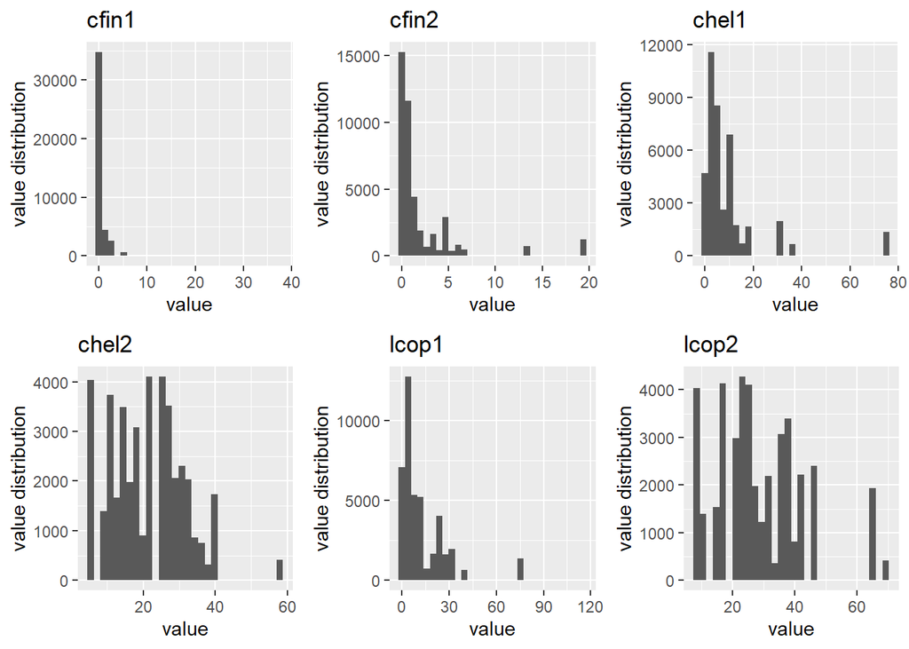

```r
grid.arrange(
  cfin1Plot,
  cfin2Plot,
  chel1Plot,
  chel2Plot,
  lcop1Plot,
  lcop2Plot,
  ncol = 3,nrow=2)
```

Widzimy, że rozkłady wartości dla atrybutów opisujących zasoby planktonu są mocno asymetryczne. Charakteryzuje je duża skośność.

### Pozostałe rozkłady wartości

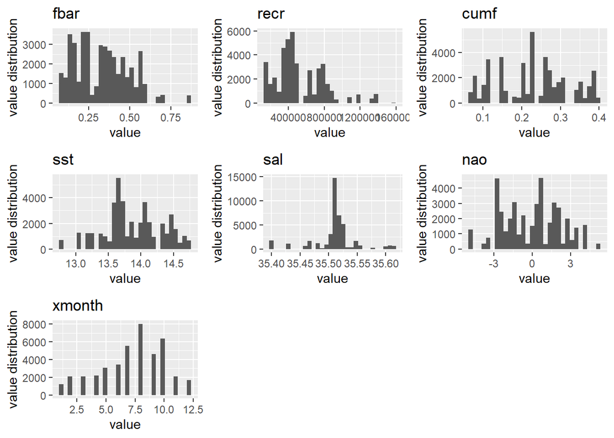

```r
grid.arrange(
  fbarPlot,
  recrPlot,
  cumfPlot,
  sstPlot,
  salPlot,
  naoPlot,
  xmonthPlot,
  ncol = 3,nrow=3)
```

Jeśli chodzi o pozostałe atrybuty, warto odnotować, iż:

- Największy połów możemy zaobserwować między czerwcem a październikiem.
- Skrajne wartości poziomu zasolenia wód stanowią mały odsetek wszystkich wartości.
- Rozkład wartości natężenia połowów w regionie przypomina rozkład gamma.

# Korelacja

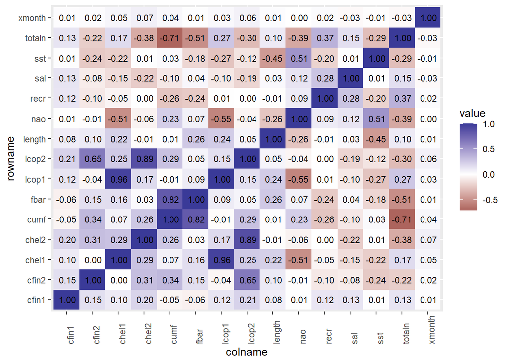

```r
sledzieT <- complete.cases(sledzie)
sledzie <- sledzie[sledzieT,]
korelacja <- cor(
  x = sledzie, use="pairwise.complete.obs")
korelacja_df = data.frame(korelacja) %>% rownames_to_column() %>% pivot_longer(-rowname, names_to="colname")
ggplot(korelacja_df, aes(colname, rowname, fill=value)) +
  geom_tile() +
  geom_text(aes(label = format(round(value, 2), nsmall = 2)), color = "black", size = 3) +
  scale_fill_gradient2() +
  theme(axis.text.x=element_text(angle = 90, hjust = 0))
```

Na podstawie macierzy korelacji, możemy stwierdzić iż:

- między atrybutem opisującym długość śledzia a atrybutem opisującym temperaturę wody przy powierzchni występuje niewielka korelacja ujemna.
- Możemy także zaobserwować podobną sytuację między temperaturą wody przy powierzchni a dostępnością planktonu.
- dostępność różnego rodzaju planktonu koreluje ze sobą dodatnio.
- oczywista wydaje się zależności całkowitej liczby złowionych śledzi z natężeniem połowów w regionie czy też całkowitym rocznym natężeniem połowów.
- ujemna korelacja występuje między niektórymi rodzajami planktonu a oscylacją północnoatlantycką.

# Interaktywny wykres rozkładu długości śledzi.

Poniższy wykres pokazuje jak zmieniała się rozkład wartości dla atrybutu **length** w kolejnych latach

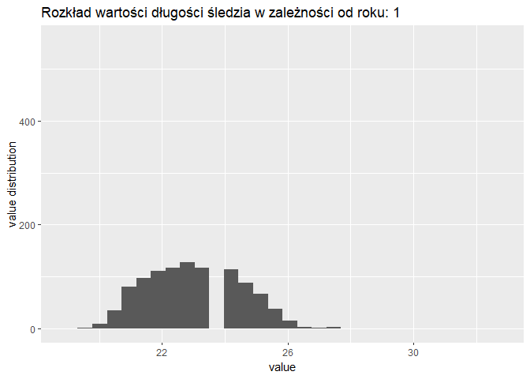

```r
p1 <- ggplot(sledzieWithYear, aes(x=sledzieWithYear$length)) +
             geom_histogram() +
             labs(title = 'Rozkład wartości długości śledzia w zależności od roku: {frame_time}', x = 'value', y = 'value distribution') +
             transition_time(as.integer(year))

animate(p1)
```

```r
anim_save('lenght_value_distribution.gif')
```

# Regresor

Opis procesu tworzenia regresora, którego zadaniem jest przewidywanie długości śledzia. Wykorzystano do tego metodę regresji liniowej.

## Podział zbioru i przygotowanie do trenowania modelu

```r
set.seed(23)
reggresion_df <- sledzie
inTraining  <- createDataPartition( y = reggresion_df$length, p=0.7, list=F)
training <- reggresion_df[ inTraining,]
testing  <- reggresion_df[-inTraining,]
```

## Uczenie modelu

```r
model <- train(
    length ~ .,
    data=training,
    trControl = trainControl(method="cv",
               number=5,
               allowParallel = TRUE,
               verboseIter = FALSE),

    method="lm"
  )
```

## Predykcja

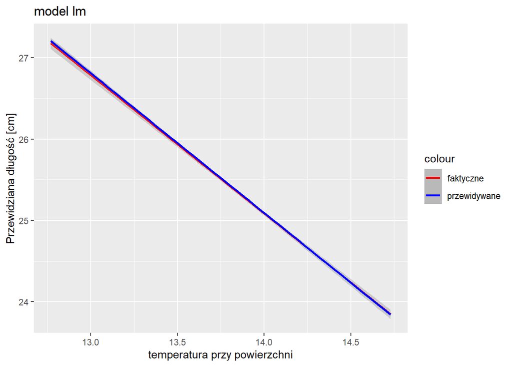

```r
predictions <- predict(model, select(testing, -c(length)))

x <- select(testing, -c(length))
  results <- testing %>%
    select(length, sst) %>%
    rename(y_correct = length)
  results$y_predicted <- predictions


  colors <- c("przewidywane" = "blue", "faktyczne" = "red")
  ggplot(results, aes( x = sst)) +
    geom_smooth(aes(y = y_correct,color="faktyczne"),method=lm )+
    geom_smooth(aes(y = y_predicted,color="przewidywane"),method=lm) +
    labs(title = paste("model", "lm"),
         x="temperatura przy powierzchni", y="Przewidziana długość [cm]")+
      scale_color_manual(values = colors)
```

trafność predykcji sprawdzono wykorzystując miary RMSE oraz R^2:

```r
  testLength <- select(testing, length)
  testMean <- mean(testLength$length)
  difference <- (testLength - predictions)

  rmse <- sqrt(mean(difference$length**2))
  rSqrd<- 1 -  sum(difference**2) / sum((testLength$length - testMean)**2)
  rmse
```

```
## [1] 1.362445
```

```r
  rSqrd
```

```
## [1] 0.3119264
```

# Analiza najważniejszych atrybutów

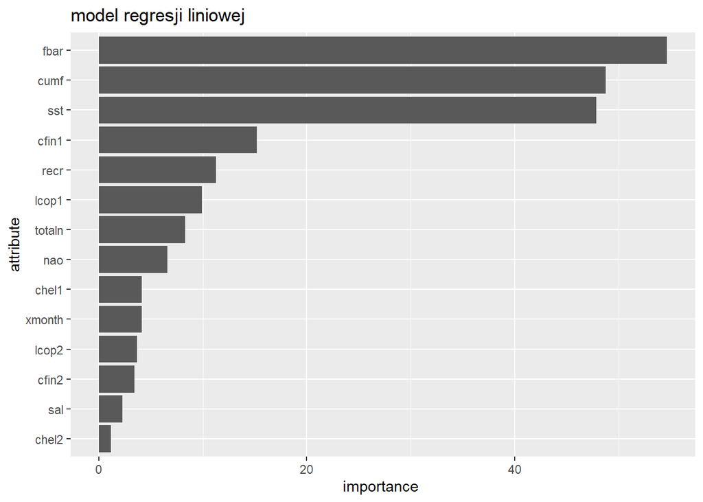

```r
atribbutesImportance <- varImp(model, scale=FALSE)

importancePlot<- ggplot(atribbutesImportance) +
    labs(title="model regresji liniowej", x="attribute", y="importance ")
importancePlot
```

Na podstawie wykresu jesteśmy w stanie stwierdzić, iż najważniejszymi atrybutami są fbar,cumf,sst

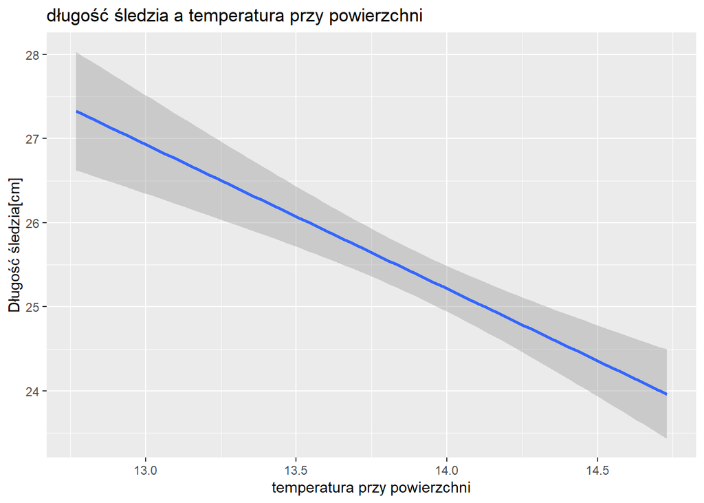

```r
attributesMean <- sledzieWithYear %>%
                  select(c(c("sst", "fbar", "cumf", "length"), "year")) %>%group_by(year) %>% summarise_all(mean)


ggplot(attributesMean,  aes(x=sst, y=length)) +
    geom_smooth(method='lm') +
    labs(title="długość śledzia a temperatura przy powierzchni",x = "temperatura przy powierzchni",y = "Długość śledzia[cm]")
```

Po dokładniejszej analizie atrybutu **sst** widzimy, że wraz ze zwiększaniem się temperatury wody przy powierzchni spada długość śledzia.

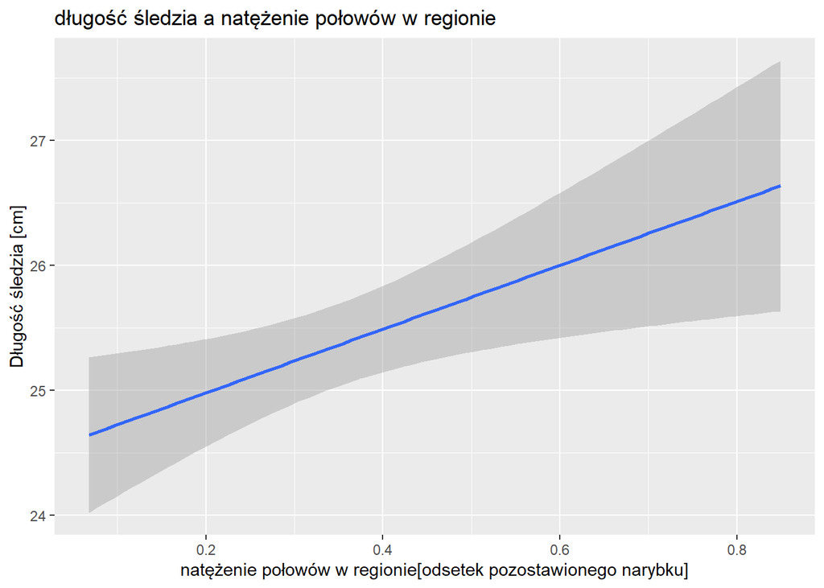

```r
ggplot(attributesMean,  aes(x=fbar, y=length)) +
    geom_smooth(method='lm') +
    labs(title="długość śledzia a natężenie połowów w regionie",
         x = "natężenie połowów w regionie[odsetek pozostawionego narybku]",
         y = "Długość śledzia [cm]")
```

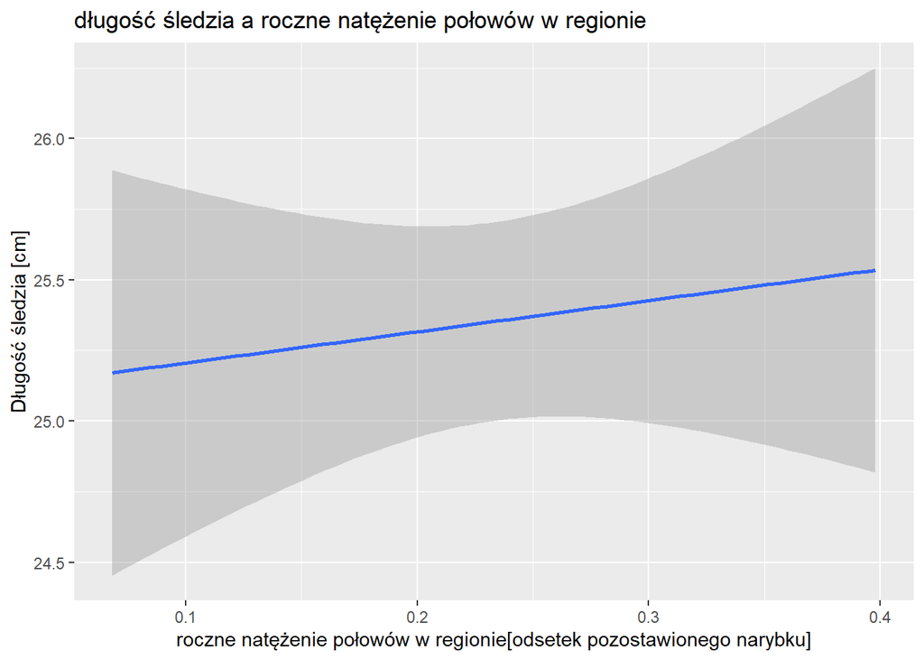

```r
ggplot(attributesMean,  aes(x=cumf, y=length)) +
    geom_smooth(method='lm') +
    labs(title=paste("długość śledzia a roczne natężenie połowów w regionie "),
         x = "roczne natężenie połowów w regionie[odsetek pozostawionego narybku]",
         y = "Długość śledzia [cm]")
```

# Podsumowanie

- Nie ma jednego konkretnego atrybutu, od którego zależy długość śledzia
- Większość atrybutów nie jest ze sobą skorelowanych - ciężko określić zależność między nimi
- Największa korelacja zachodzi między dostępnością niektórych rodzajów planktonu - można na tej podstawie stwierdzić, iż dogodne warunki dla jednego rodzaju są także odpowiednie dla drugiego.
- Innym przykładem korelacji wśród rozpatrywanych atrybutów jest natężenie połowów a całkowita liczba złowionych śledzi - uzasadnienie jest tutaj niepotrzebne *Najważniejszymi atrybutami branymi pod uwagę przy przewidywaniu długości śledzia są:
  - **sst**
  - **cumf**
  - **fbar**